# Lab | Introduction to R and Tidyverse

# Task 1: Explore the Data

**3.** Use the summary() function to get a summary of the data.

```r
summary(employees)
```

```
       ID           Name                Age         Department            Salary
 Min.   :1.00   Length:6           Min.   :25.00   Length:6           Min.   :50000
 1st Qu.:2.25   Class :character   1st Qu.:31.25   Class :character   1st Qu.:56250
 Median :3.50   Mode  :character   Median :37.50   Mode  :character   Median :65000
 Mean   :3.50                      Mean   :37.50                      Mean   :65000
 3rd Qu.:4.75                      3rd Qu.:43.75                      3rd Qu.:73750
 Max.   :6.00                      Max.   :50.00                      Max.   :80000
```

## Task 2: Basic Data Manipulation with dplyr

**1.** Filter rows: Create a new data frame that includes only employees who work in the “IT” department.

```r
filtered_employees <- employees %>% filter(Department == "IT")
print(filtered_employees)
```

| ID | Name | Age | Department | Salary |
| --- | --- | --- | --- | --- |
| 2 | Bob | 30 | IT | 60000 |
| 4 | David | 40 | IT | 80000 |

**2.** Select columns: Create a new data frame that includes only the Name and Salary columns.

| Name | Salary |
| --- | --- |
| Alice | 50000 |
| Bob | 60000 |
| Charlie | 70000 |
| David | 80000 |
| Eve | 55000 |
| Frank | 75000 |

```r
updated_df = new_df %>% mutate(Bonus = Salary * 1.1 )
print(updated_df)
```

| Name | Salary | Bonus |
| --- | --- | --- |
| Alice | 50000 | 55000 |
| Bob | 60000 | 66000 |
| Charlie | 70000 | 77000 |
| David | 80000 | 88000 |
| Eve | 55000 | 60500 |
| Frank | 75000 | 82500 |

**4.**Sort rows: Sort the employees data frame by Salary in descending order.

```r
sorted_df <- employees %>% arrange(desc(Salary))
print(sorted_df)
```

| ID | Name | Age | Department | Salary |
| --- | --- | --- | --- | --- |
| 4 | David | 40 | IT | 80000 |
| 6 | Frank | 50 | Finance | 75000 |
| 3 | Charlie | 35 | Finance | 70000 |
| 2 | Bob | 30 | IT | 60000 |
| 5 | Eve | 45 | HR | 55000 |
| 1 | Alice | 25 | HR | 50000 |

**5.**Summarize data: Calculate the average salary for each department.

```r
av_sal_tot <- employees %>% summarize (mean(Salary))
print(av_sal_tot)
```

| mean(Salary) |
| --- |
| 65000 |

```r
av_sal_dep <- employees %>% group_by(Department) %>% summarize(Average_Salary = mean(Salary, na.rm = TRUE))  # The na.rm = TRUE part ensures that any NA values are ignored when calculating the mean.
print(av_sal_dep)
```

| Department | Average_Salary |
| --- | --- |
| Finance | 72500 |
| HR | 52500 |
| IT | 70000 |

```r
NA
```

## Optional Exercises

### **Extra 1**: Advanced Data Manipulation

**1.** Group and summarize: Group the data by Department and calculate the total salary expenditure for each department.

```r
sal_exp <- employees %>% group_by(Department) %>% summarize(dep_exp = sum(Salary, na.rm = TRUE))
print(sal_exp)
```

| Department | dep_exp |
| --- | --- |
| Finance | 145000 |
| HR | 105000 |
| IT | 140000 |

```r
NA
```

**2.** Filter and mutate: Create a new data frame that includes only employees older than 30 and adds a column called Experience that assumes each employee has Age - 25 years of experience.

```r
fil_mut_df <- employees %>% filter(Age > 30) %>% mutate(Experience = Age - 25)
print(fil_mut_df)
```

| ID | Name | Age | Department | Salary | Experience |
| --- | --- | --- | --- | --- | --- |
| 3 | Charlie | 35 | Finance | 70000 | 10 |
| 4 | David | 40 | IT | 80000 | 15 |
| 5 | Eve | 45 | HR | 55000 | 20 |
| 6 | Frank | 50 | Finance | 75000 | 25 |

### Extra 2: Challenge

```r
hr_df <- employees %>% filter(Department == "HR") %>% mutate(Bonus = Salary * 1.1 ) %>% arrange(desc(Bonus))
print(hr_df)
```

| ID | Name | Age | Department | Salary | Bonus |
| --- | --- | --- | --- | --- | --- |
| 5 | Eve | 45 | HR | 55000 | 60500 |
| 1 | Alice | 25 | HR | 50000 | 55000 |

**2.** Visualize data: Use ggplot2 to create a bar plot showing the total salary expenditure by department.

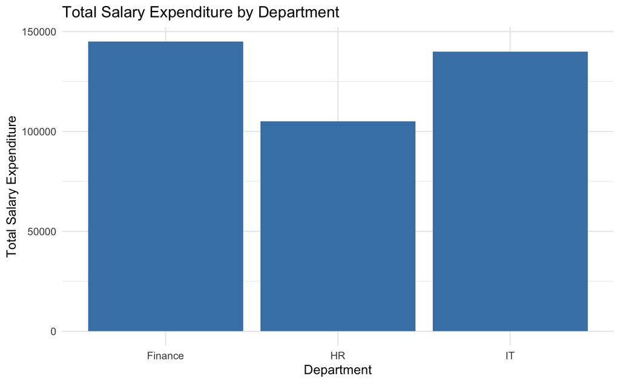

```r
# Create the bar plot
ggplot(sal_exp, aes(x = Department, y = dep_exp)) +
  geom_bar(stat = "identity", fill = "steelblue") +
  labs(title = "Total Salary Expenditure by Department",
       x = "Department",
       y = "Total Salary Expenditure") +
  theme_minimal()
```